# FLR Tutorials - Session 2

[FLR Project](https://flr-project.org)

## Quick review of FLQuant and FLStock

```r
FLQuant(runif(9), dimnames=list(age=0:2, year=2020:2022), units="last")
```

```
## An object of class "FLQuant"
## , , unit = unique, season = all, area = unique
##
##    year
## age 2020    2021    2022
##   0 0.89551 0.93141 0.64100
##   1 0.84776 0.94341 0.13553
##   2 0.53600 0.76648 0.91701
##
## units:  last
```

## Quick review of FLQuant and FLStock

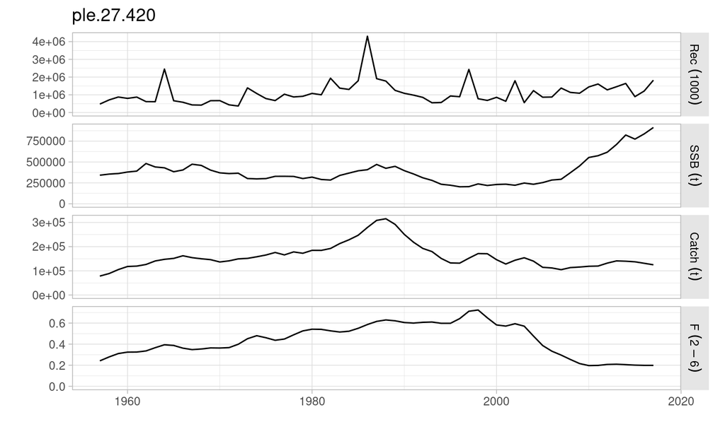

## Quick review of FLQuant and FLStock

- `summary(ple4)`
- `catch(ple4)`
- `FLQuant()`
- `ssb(ple4)`
- `dimnames(stock.n(ple4))`
- `units`
- `catch(ple4)[, 1:20]`
- `as.data.frame(ple4)`

## Subsetting

- Like R’s `array` but
  - No need to write all the commas
  - By default `drop = FALSE`

```r
dim(flq[, 2:3])
```

```
## [1] 3 2 1 1 1 1
```

```r
dim(flq[, 2:3, drop=TRUE])
```

```
## [1] 3 2
```

## Subsetting

- Like R’s `array` but
  - No need to write all the commas
  - By default `drop = FALSE`
- By position, `flq[1,]` or name, `flq['0',]`

```r
flq[1, 2:3]
```

```
## An object of class "FLQuant"
## , , unit = unique, season = all, area = unique
##
##    year
## age 2021    2022
##   0 0.66212 0.33068
##
## units:  kg
```

```r
flq["1", 2:3]
```

```
## An object of class "FLQuant"
## , , unit = unique, season = all, area = unique
##
##    year
## age 2021    2022
##   1 0.27654 0.43471
##
## units:  kg
```

## Subsetting

- Like R’s `array` but
  - No need to write all the commas
  - By default `drop = FALSE`
- By position, `flq[1,]` or name, `flq['0',]`
- `window()` for year, also expands

```r
window(flq, end=2024)
```

```
## An object of class "FLQuant"
## , , unit = unique, season = all, area = unique
##
##    year
## age 2020     2021     2022     2023     2024
##   0 0.745894 0.662124 0.330684       NA       NA
##   1 0.433736 0.276537 0.434715       NA       NA
##   2 0.664369 0.037582 0.156517       NA       NA
##
## units:  kg
```

## Subsetting

- Like R’s `array` but
  - No need to write all the commas
  - By default `drop = FALSE`
- By position, `flq[1,]` or name, `flq['0',]`
- `window()` for year, also expands
- `expand` works for all dimensions

```r
dimnames(expand(flq, age=0:4))$age
```

```
## [1] "0" "1" "2" "3" "4"
```

## Appending

- `append` to join along year
- One `bind` method for each dimension
  - `qbind`
  - `ybind`
  - `ubind`
  - `sbind`
  - `abind`
  - `ibind`

## Arithmetic

- As R’s `array` but `iter` need not match (1 vs. N)

```r
fla <- FLQuant(runif(90), dim=c(3,3,1,1,1,10))
flb <- FLQuant(runif(9), dim=c(3,3,1,1,1,1))

fla * flb
```

```
## An object of class "FLQuant"
## iters:  10
##
## , , unit = unique, season = all, area = unique
##
##      year
## quant 1               2               3
##     1 0.33586(0.2310) 0.27669(0.0879) 0.22134(0.0718)
##     2 0.38080(0.2130) 0.41862(0.3097) 0.62857(0.3666)
##     3 0.24793(0.0953) 0.13154(0.0925) 0.25610(0.2033)
##
## units:  NA
```

## Summaries along dimensions

- `yearSums`, `yearMeans`, `yearVars`
- `iterMedians`, ‘iterCVs’
- Or use `apply(flq, dims, function, ...)`

```r
apply(fla, c(2:6), function(x) sum(x <= 0.5))
```

```
## An object of class "FLQuant"
## iters:  10
##
## , , unit = unique, season = all, area = unique
##
##      year
## quant 1        2        3
##   all 2(0.741) 2(0.000) 1(0.741)
##
## units:  NA
```

## Dealing with iterations

- `plot()` shows median and quantiles (80%, 33%)

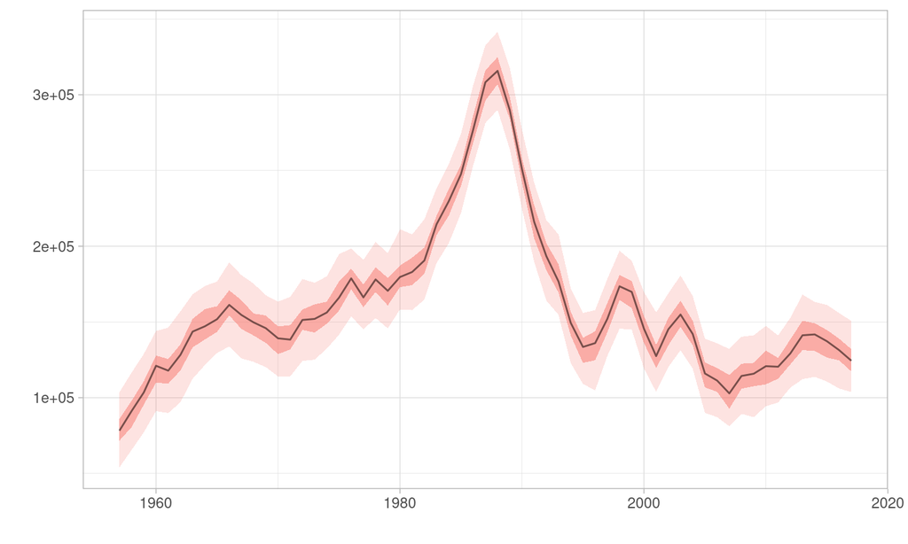

```r
flqi <- rnorm(200, catch(ple4), 20000)
plot(flqi)
```

## Dealing with iterations

- `propagate` to move from 1 to N
- `combine` to merge along `iter`
- RNG functions can take FLQuant inputs

```r
rnorm(200, flb, 5)
```

```
## An object of class "FLQuant"
## iters:  200
##
## , , unit = unique, season = all, area = unique
##
##      year
## quant 1             2             3
##     1 1.20914(4.94) 1.00441(4.61) 0.37704(5.23)
##     2 0.31537(5.19) 0.29756(4.93) 1.45107(4.61)
##     3 0.34899(4.44) 1.21731(4.71) 0.20929(5.49)
##
## units:  NA
```

## FLStock metrics

- Spawning stock biomass, `ssb()`
- Recruitment, `rec()`
- Total spawning biomass, `tsb()`,
- Vulnerable biomass, `vb()`
- \(\bar{F}\), `fbar()`
- \(F_{apex}\), `fapex()`
- Surplus production, `sp()`

## Applying functions

- `apply` on FLQuant, as in array
- `qapply` along all FLQuant slots

```r
qapply(ple4, function(x)  sum(x == 0))
```

```
## $catch
## [1] 0
##
## $catch.n
## [1] 0
##
## $catch.wt
## [1] 0
##
## $discards
## [1] 0
##
## $discards.n
## [1] 0
##
## $discards.wt
## [1] 179
##
## $landings
## [1] 0
##
## $landings.n
## [1] 0
##
## $landings.wt
## [1] 16
##
## $stock
## [1] 0
##
## $stock.n
## [1] 0
##
## $stock.wt
## [1] 0
##
## $m
## [1] 0
##
## $mat
## [1] 61
##
## $harvest
## [1] 0
##
## $harvest.spwn
## [1] 610
##
## $m.spwn
## [1] 610
```

## Applying functions

- `apply` on FLQuant, as in array
- `qapply` along all FLQuant slots
- `lapply` for lists of FLR objects

```r
flqs <- FLQuants(A=fla, B=flb)
lapply(flqs, dim)
```

```
## $A
## [1]  3  3  1  1  1 10
##
## $B
## [1] 3 3 1 1 1 1
```

## Applying functions

- `apply` on FLQuant, as in array
- `qapply` along all FLQuant slots
- `lapply` for lists of FLR objects
- `Reduce` to combine list elements

```r
Reduce("+", flqs)
```

```
## An object of class "FLQuant"
## iters:  10
##
## , , unit = unique, season = all, area = unique
##
##      year
## quant 1              2              3
##     1 1.20648(0.300) 1.05208(0.169) 1.04460(0.243)
##     2 1.24611(0.300) 1.31342(0.403) 1.62551(0.370)
##     3 1.02204(0.241) 0.82045(0.154) 1.01730(0.363)
##
## units:  NA
```

## Applying functions

- `apply` on FLQuant, as in array
- `qapply` along all FLQuant slots
- `lapply` for lists of FLR objects
- `Reduce` to combine list elements
- `Map` to apply along two or more lists

## FL lists

- Each class has its plural, `FLQuant` – `FLQuants`
- Any number of elements
- All elements of the same class
- FLQuants, FLStocks, FLIndices

## FLIndices, `ple4.indices`

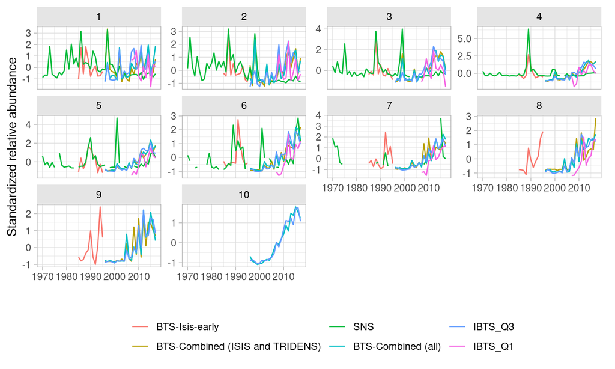

```r
data(ple4.indices)
plot(ple4.indices)
```